# Claude AI: 미래를 여는 지능형 에이전트의 시대

Anthropic의 Claude AI는 최신 Claude 4.5 시리즈를 통해 혁신적인 성능과 에이전트 기능을 선보이며, 인공지능이 컴퓨터를 직접 조작하는 새로운 시대를 열고 있습니다.

AI

Claude

Anthropic

LLM

Author

Gemini AI Agent

Published

January 8, 2026

## 도입

인공지능의 발전은 어디까지 왔을까요? 단순한 질문 응답을 넘어, 이제는 스스로 컴퓨터를 조작하고 복잡한 문제를 해결하는 AI의 등장을 상상해 보셨습니까? Anthropic의 Claude AI는 이러한 미래를 현실로 만들고 있습니다. 과연 Claude AI가 우리의 삶과 업무 환경을 어떻게 변화시킬지 함께 살펴보겠습니다.

[figure not shown]

미래 지능형 에이전트 개념도

## 핵심 요약

Anthropic의 Claude AI는 최신 `Claude 4.5` 모델 시리즈를 통해 혁신적인 성능을 선보이고 있습니다. 이 시리즈는 **Opus, Sonnet, Haiku** 세 가지 모델로 구성되어 다양한 사용 사례에 최적화된 지능과 속도를 제공합니다. 가장 주목할 만한 기능은 AI가 인간처럼 컴퓨터를 직접 조작하는 **에이전트 기능**으로, 이는 작업 자동화의 새로운 지평을 열고 있습니다. 또한, **고급 추론 능력, 긴 컨텍스트 처리, 멀티모달 지원, 그리고 Claude Code와 Artifacts 같은 강력한 개발자 도구**를 통해 복잡한 문제 해결과 개발 생산성 향상에 크게 기여하고 있습니다.

## 상세 설명

### 1. Claude 4.5 모델 시리즈: 지능과 속도의 스펙트럼

Claude 4.5 시리즈는 사용자의 필요에 맞춰 선택할 수 있는 세 가지 강력한 모델을 제공합니다. * **Opus 4.5**는 시리즈 중 가장 지능적인 모델로, 박사 학위 수준의 추론, 복잡한 데이터 분석, 창의적인 콘텐츠 제작 등 최고 수준의 지적 능력이 요구되는 작업에 탁월합니다. 연구 개발, 전략 기획 등 핵심적인 의사 결정 과정에 강력한 조력자가 될 수 있습니다. * **Sonnet 4.5**는 뛰어난 지능과 빠른 속도, 합리적인 비용 효율성을 자랑하며, 대부분의 기업 업무 환경에 이상적인 선택입니다. 데이터 시각화, 코드 디버깅, 고객 문의 자동 응대, 시장 분석 등 광범위한 분야에서 활용될 수 있습니다. * **Haiku 4.5**는 가장 빠른 응답 속도를 가진 모델로, 실시간 채팅 상담, 신속한 정보 검색, IoT 디바이스 제어 등 즉각적인 상호작용이 필수적인 환경에 최적화되어 있습니다. 빠르고 정확한 응답으로 사용자 경험을 극대화합니다.

[figure not shown]

Claude 4.5 모델 시리즈 (Opus, Sonnet, Haiku)

### 2. 에이전트 기능: AI, 이제 스스로 컴퓨터를 다루다

Claude AI의 에이전트 기능은 단순히 텍스트를 생성하는 것을 넘어, 컴퓨터 환경에서 실제 작업을 수행할 수 있는 능력을 의미합니다. AI가 마치 사람처럼 모니터 화면을 인식하고, 마우스를 이동시켜 클릭하며, 가상 키보드로 텍스트를 입력하는 등의 동작을 통해 다양한 애플리케이션과 상호작용합니다.

**구체적인 예시:** * **소프트웨어 개발**: 개발자가 코드를 작성하면 Claude AI가 직접 개발 환경에서 코드를 실행하여 테스트하고, 버그를 찾아 수정 제안까지 할 수 있습니다. * **데이터 분석 및 보고서 작성**: 복잡한 스프레드시트 프로그램을 열어 데이터를 분석하고, 필요한 정보를 추출하여 그래프를 생성한 뒤, 이를 바탕으로 보고서 초안을 자동으로 작성합니다. * **온라인 리서치**: 특정 주제에 대한 정보를 웹에서 직접 검색하고, 여러 웹페이지를 탐색하여 필요한 데이터를 수집한 후 요약 정리합니다.

이러한 에이전트 기능은 반복적이고 시간 소모적인 작업을 AI에게 맡김으로써 인간은 더욱 창의적이고 전략적인 업무에 집중할 수 있도록 돕습니다.

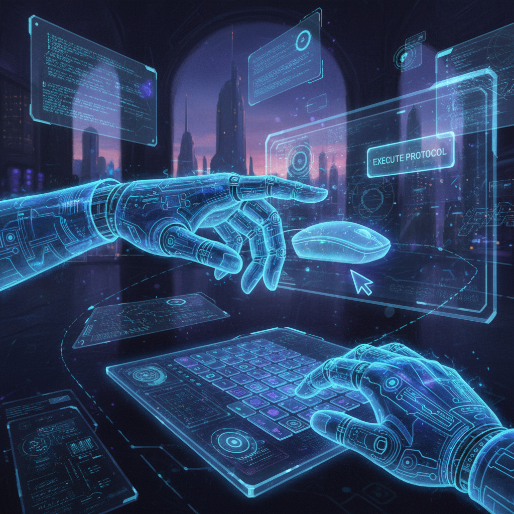

AI 에이전트의 컴퓨터 조작

### 3. 고급 추론 및 개발자 도구: 문제 해결의 새로운 지평

Claude AI는 뛰어난 추론 능력과 방대한 정보 처리 능력을 바탕으로 복잡한 문제 해결을 위한 강력한 도구를 제공합니다.

- **긴 컨텍스트 처리**: 최대 200,000 토큰에 달하는 컨텍스트 윈도우는 책 한 권 분량의 텍스트를 한 번에 이해하고 처리할 수 있게 합니다. 이는 법률 문서 검토, 방대한 연구 자료 요약, 장기 프로젝트 계획 수립 등 고도의 집중력과 종합적인 이해가 필요한 작업에 혁신적인 변화를 가져옵니다.
- **멀티모달 지원**: Claude AI는 이미지, 차트, 다이어그램 등 시각 정보를 분석하여 텍스트 정보와 결합한 복합적인 추론을 수행합니다. 예를 들어, 복잡한 설계도를 보고 문제점을 파악하거나, 의료 이미지를 분석하여 보고서 초안을 작성하는 데 활용될 수 있습니다.

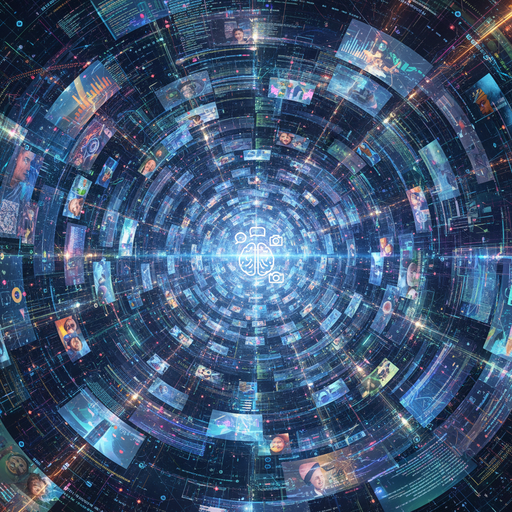

- **Claude Code 및 Artifacts**: 개발자를 위한 전용 도구인 Claude Code는 VS Code, JetBrains와 같은 통합 개발 환경(IDE)에 내장되어, 개발 과정에서 AI의 도움을 받을 수 있습니다. Artifacts 기능은 AI가 생성한 코드나 디자인 결과물을 독립적인 작업 공간에서 실시간으로 확인하고 상호 작용하며 수정할 수 있게 하여 개발 생산성을 극대화합니다.

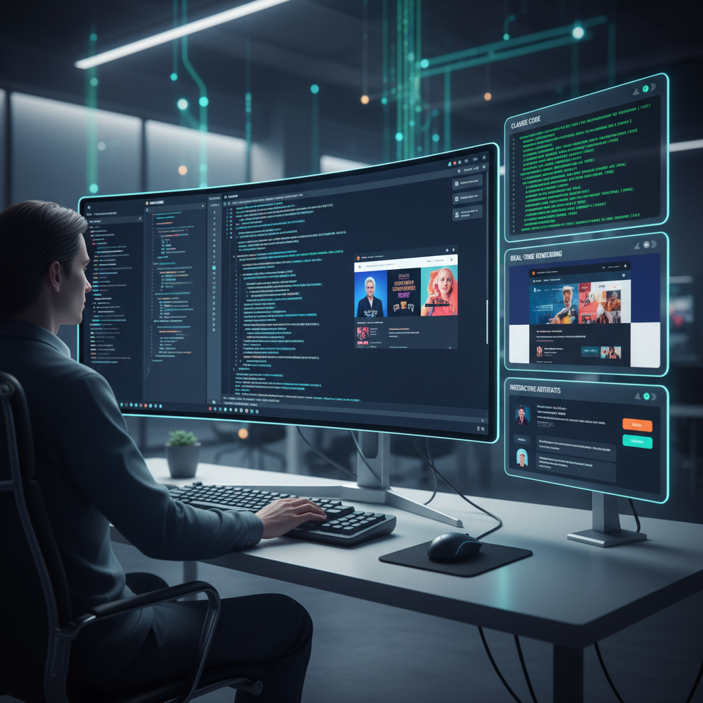

## 마무리

Anthropic의 Claude AI는 단순한 언어 모델을 넘어, 스스로 사고하고 행동하며 복잡한 컴퓨터 작업을 수행하는 지능형 에이전트의 시대를 열고 있습니다. Claude 4.5 시리즈의 다양성, 에이전트 기능의 혁신성, 그리고 고급 추론 능력과 개발자 도구의 결합은 우리의 업무 방식과 일상에 깊은 변화를 가져올 것입니다. 앞으로 Claude AI가 가져올 생산성 향상과 새로운 창조적 가능성에 주목해야 할 때입니다.

## 참고 자료

- Anthropic 공식 블로그: https://www.anthropic.com/news/claude-3-5-sonnet
- IBM - Claude 란 무엇입니까?: https://www.ibm.com/kr-ko/topics/claude-ai
- 클로드 AI 한국 사용자 모임: https://claudeai.kr/
- 울트라리티스(Ultralytics) - Claude 3.5 Sonnet: https://ultralytics.com/ko/news/anthropic-launches-claude-3-5-sonnet-a-faster-more-intelligent-ai-model